# Investigating Factors Impacting Movie Profits: A Machine Learning Analysis

Author: Sofía Martina Villamil Erosa

Tutor: Elen Irazábal

## Introduction

- The primary objective of my thesis was to develop a machine learning model capable of accurately explaining which factors affect movie profits. This involves identifying the key factors that significantly impact the profitability of movies.
- This research covers movies released between 2012 and 2023, using data from major movie websites.
- This study is motivated by the anticipated significant losses in the movie industry, underscoring the urgent need for a reliable machine learning model.

## Literature Review

- The existing literature on box-office revenues analysis for films is extensive, yet results are mixed.
- Some studies attribute forecasting accuracy to specific variables, while others find no impact.
- This review aims to identify the variables that should be included in our research, considering various methodologies and their reported significance.

## Methodology

### Data Acquisition

- Data was acquired from major movie websites such as IMDb, Rotten Tomatoes, Box Office Mojo, The Movie Data Base and The Numbers.
- Additional data related to social media metrics was collected from YouTube and Instagram.

### Data Processing

- The data underwent pre-processing and normalization before being used to train various machine learning models.
- New variables were introduced based on hypotheses regarding their potential impact on the dependent variable.
- The dependent variable “Profit” was calculated using the equation:

  Profit<sub>i</sub> = 0.5 × Worldwide Gross<sub>i</sub> - Budget<sub>i</sub>

  where *i* ranges from 1 to 2464 observations.

### Independent Variables

| Independent Variable Names | Type Of Variable | Range of Possible Categories |
| --- | --- | --- |
| Genre | Dummy | Action, Adventure, Animation, Biography, Comedy, Crime, Documentary, Drama, Fantasy, Horror, Mystery |
| Lead is a woman | Binary | Yes = 1, No = 0 |
| MPAA | Dummy | General Audiences, Not Rated, Parental Guidance Suggested, Parents Strongly Cautioned, Restricted |
| Duration of the movie | Numeric | Length of the movie in minutes |
| Month of release | Dummy | Month 1 - Month 12 |
| Movie Age | Numeric | Age of the movie in years since release |
| If it’s a weekend | Binary | Yes = 1, No = 0 |
| Movie Score | Numeric | Aggregated score based on IMDB and Rotten Tomatoes |
| Season | Dummy | Winter, Fall, Summer, Spring |
| First Actor Score | Numeric | Score based on awards and number of movies the first actor has been in |
| Second Actor Score | Numeric | Score based on awards and number of movies the second actor has been in |
| Director Score | Numeric | Score based on awards and number of movies the director has been in |
| Overall Sentiment Score | Numeric | Average sentiment score based on reviews |
| View Count in Trailer | Numeric | Number of views the trailer has on YouTube |
| Instagram Followers | Numeric | Number of Instagram followers of the actor |

### The Models

- The models selected based on previous literature were the following: Artificial Neural Networks (ANN), Support Vector Machines (SVM), and an Ensemble model.
- Variables were selected using correlation analysis and Variance Inflation Factor (VIF) to avoid multicollinearity.
- Boruta test was used for feature selection in the ANN model.

## Results

| MODEL | RMSE | R² |
| --- | --- | --- |
| Ensemble Model | 0.057 | 0.203 |
| Artificial Neural Network (ANN) | 0.060 | 0.192 |
| Support Vector Machine (SVM) | 0.063 | 0.180 |
| Support Vector Machine Extra | 0.156 | 0.047 |

## Discussion

### Variable Importance Plot

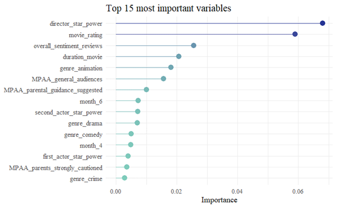

### Partial Dependence Plot

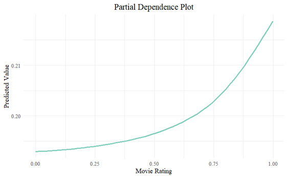

## The End

I am now available to answer any questions you may have.

## References

- Tartaglione, N. (2024). International box office 2023 global studio rankings, market share. Deadline. Retrieved from https://deadline.com/2024/01/international-box-office-2023-global-studio-rankings-market-share-1235709538/
- Rhee, T. G., & Zulkernine, F. (2016). Predicting movie box office profitability: a neural network approach. In 2016 15th IEEE International Conference on Machine Learning and Applications (ICMLA) (pp. 665-670). IEEE.
- Asur, S., & Huberman, B. A. (2010). Predicting the future with social media. In 2010 IEEE/WIC/ACM international conference on web intelligence and intelligent agent technology (Vol. 1, pp. 492-499). IEEE.
- Ainslie, A., Drèze, X., & Zufryden, F. (2005). Modeling movie life cycles and market share. Marketing science, 24(3), 508-517.
- Ahmed, U., Waqas, H., & Afzal, M. T. (2020). Pre-production box-office success quotient forecasting. Soft Computing, 24(9), 6635-6653.
- Google. (2024). Retrieved from https://www.google.com
- Eliashberg, J., Elberse, A., & Leenders, M. A. (2006). The motion picture industry: Critical issues in practice, current research, and new research directions. Marketing science, 25(6), 638-661.
- Sawhney, M. S., & Eliashberg, J. (1996). A parsimonious model for forecasting gross box-office revenues of motion pictures. Marketing Science, 15(2), 113-131.
- Zhou, Y., Zhang, L., & Yi, Z. (2019). Predicting movie box-office revenues using deep neural networks. Neural Computing and Applications, 31, 1855-1865.
- YouTube, 2024. Retrieved from https://www.youtube.com/.
- Zhang, L., Luo, J., & Yang, S. (2009). Forecasting box office revenue of movies with BP neural network. Expert Systems with Applications, 36(3), 6580-6587.
- Sharda, R., & Delen, D. (2006). Predicting box-office success of motion pictures with neural networks. Expert Systems with Applications, 30(2), 243-254.
- Litman, B. R. (1983). Predicting success of theatrical movies: An empirical study. Journal of popular culture, 16(4), 159.
- TMDB API Version 3. (2024). Retrieved from: https://developer.themoviedb.org/docs/getting-started
- Internet Movie Database. (2024). Retrieved from http://www.IMDb.com/
- Box Office Mojo. (2024). Retrieved from http://www.boxofficemojo.com/
- The Numbers. (2024). Retrieved from http://www.the-numbers.com/
- TMDB. (2024). Retrieved from https://www.themoviedb.org/
- Nelson, R. A., & Glotfelty, R. (2012). Movie stars and box office revenues: an empirical analysis. Journal of Cultural Economics, 36, 141-166.
- Asaniczka. (2023). TMDB Movies Dataset [Data set]. Kaggle. Retrieved from https://www.kaggle.com/datasets/asaniczka/tmdb-movies-dataset-2023-930k-movies
- Ghiassi, M., Lio, D., & Moon, B. (2015). Pre-production forecasting of movie revenues with a dynamic artificial neural network. Expert Systems with Applications, 42(6), 3176-3193.
- Lee, K., Park, J., Kim, I., & Choi, Y. (2018). Predicting movie success with machine learning techniques: ways to improve accuracy. Information Systems Frontiers, 20, 577-588.
- Zhang, W., & Skiena, S. (2009). Improving Movie Gross Prediction through News Analysis. In Proceedings of the 2009 IEEE/WIC/ACM International Joint Conference on Web Intelligence and Intelligent Agent Technology, vol. 1, pp. 301-304, IEEE Computer Society, Washington, DC, USA.
- D’Alessandro, A. (2023). Box office 2024 predictions: Movies, cinemas. Deadline. Retrieved from https://deadline.com/2023/12/box-office-2024-predictions-movies-cinemas-1235682149/
- Delen, D., & Sharda, R. (2010). Predicting the financial success of Hollywood movies using an information fusion approach. Industrial Engineering Journal, 21(1), 30-37.
- Rotten Tomatoes, 2024. Retrieved from http://www.rottentomatoes.com/.

[figure not shown]